# DSGE estimation

Andrew P Blake

October 2020

> *Disclaimer: The Bank of England does not accept any liability for misleading or inaccurate information or omissions in the information provided. The subject matter reflects the views of the individual presenter and not the wider Bank of England or its Policy Committees.*

## Putting it all together

- Can we apply all of the techniques necessary to estimate a DGSE model in R?
- In the immortal words of somebody, “Yes we can!”
- Need to pass parameters to a model, solve it, map the data to it, choose new parameters, do it all again until we decide on convergence
- Can do this pure maximum likelihood or via Metropolis-Hastings
- Would be useful if we can initialise MH search effectively

## This is how we do it

### Model

```r
model_file <- function(theta) {

  nf    <- 2
  ns    <- 6
  np    <- ns-nf
  nx    <- np+1

  beta  <- 0.99   #  calibrated
  sigma <- theta[1]
  kappa <- theta[2]
  delta <- theta[3]
  gamma <- theta[4]
  rho_1 <- theta[5]
  rho_2 <- theta[6]
  rho_3 <- theta[7]
  Omega <- diag(theta[c(8:10)])

  labels <- c("eta[1]","eta[2]","eta[3]","i","y","pi")

  E <- matrix(0,ns,ns)
  A <- E
  G <- diag(1,ns,3)

  diag(E[1:3,1:3]) <- 1
  diag(A[1:3,1:3]) <- c(rho_1, rho_2, rho_3)

  E[4,c(3, 4)]       <- c(-1, 1)
  E[5,c(1, 4, 5, 6)] <- c(1, -1/sigma, 1, 1/sigma)
  E[6,c(2, 6)]       <- c(1, beta)

  A[4,c(4, 6)]       <- c(gamma, (1-gamma)*delta)
  A[5,5]             <- 1
  A[6,c(5,6)]        <- c(-kappa, 1)

  AA <- solve(E,A)
  BB <- solve(E,G)
  m  <- eigen(AA)

  Lambda <- diag(m$values)
  # print(Lambda[abs(Lambda)>1])
  M      <- solve(m$vectors[,ns:1])
  N      <- -Re(solve(M[nx:ns,nx:ns])%*%M[nx:ns,1:np])
  G      <- -solve((AA[nx:ns,nx:ns]-N%*%AA[1:np,nx:ns]), (BB[nx:ns,]-N%*%BB[1:np,]))
  PP     <- cbind(rbind((AA[1:np,1:np] + (AA[1:np,nx:ns] %*% N)), N), matrix(0,ns,nf))
  QQ     <- rbind(BB[1:np,] + AA[1:np,nx:ns] %*% G, G)



  return(list(PP, QQ, Omega, labels))
}
```

## Likelihood

### Kalman filter

```r
likelihood <- function(theta, y) {

  #  Code to evaluate the likelihood of a RE model via the Kalman filter
  t <- nrow(y)

  # Model solution to obtain state space form
  # Returns F, V, Sigma, H
  modl  <- model_file(theta)
  F     <- modl[[1]]
  V     <- modl[[2]]
  Sigma <- modl[[3]]

  H       <- matrix(0, 3, 6)
  H[1, 5] <- 1
  H[2, 6] <- 1
  H[3, 4] <- 1

  # COMPUTE MATRICES OF THE STATE SPACE
  # Y   = H*S
  # S_t = F*S_[t-1] + eta
  # Var(eta) = Q, where Q = QQ*Sigma*QQ'

  ns     <- dim(F)[1]
  Q      <- V %*% Sigma %*% t(V)
  mu     <- 0L
  lik    <- 0L
  const  <- -log(2*pi)

  # filter
  beta0  <- matrix(0, 1, ns)
  p00    <- diag(ns)*10000
  R      <- 0
  # Prediction
  beta10 <- mu + beta0 %*% t(F)
  p10    <- F %*% p00 %*% t(F) + Q
  eta    <- y[1,] - beta10 %*% t(H)
  feta   <- H %*% p10 %*% t(H) + R
  ifeta  <- qr.solve(feta)
  # updating
  K      <- p10 %*% t(H) %*% ifeta
  beta11 <- beta10 + eta %*% t(K)
  p11    <- p10 - K %*% H %*% p10

  for (i in 2:t) {
    # Prediction
    beta10 <- mu + beta11 %*% t(F)
    p10    <- F %*% p11 %*% t(F) + Q
    eta    <- y[i, ] - beta10 %*% t(H)
    feta   <- H %*% p10 %*% t(H) + R
    ifeta  <- qr.solve(feta)
    # updating
    K      <- p10 %*% t(H) %*% ifeta
    beta11 <- beta10 + eta %*% t(K)
    p11    <- p10 - K %*% H %*% p10

    liki   <- const - log(det(feta)) - eta %*% ifeta %*% t(eta)
    lik    <- lik + liki
  }
  return(0.5*lik)
}
```

### –Likelihood

```r
minus_likelihood <- function(theta,y,bounds) {
  # Calls (log)likelihood function
  # See also: LIKELIHOOD

  # Check if parameters outside bounds
  if (sum(theta<=bounds[,1] | theta>=bounds[,2]) > 0) {
    val <- 10000
    }
  else {
    val <- -likelihood(theta,y)
    }
  return(val)
}
```

## Initialise

We need to initialise what we need later

```r
library(tidyverse)
library(readxl)
library(actuar)

source("csminwel/csminwel.R")
source("csminwel/numgrad.R")
source("csminwel/numHess.R")
source("csminwel/csminit.R")
source("csminwel/bfgsi.R")

# source("model_file.R")
source("ir.R")
source("priors.R")
source("logprior.R")
source("ml_ci.R")
source("posterior.R")
source("minus_posterior.R")
```

Set up parameters, priors, read data

```r
iters  <- 20000       # Periods of the MH
burn   <- 0.8*iters
nimp   <- 14          # No. periods form imp response

# Read data
pvalues <- read_excel("Exercise.xls", sheet = "Prior values")
dvalues <- read_excel("Exercise.xls", sheet = "Data values")
knitr::kable(pvalues, caption = "Priors (from file)")
```

Priors (from file)

| Parameter name | Starting value | Lower bound | Upper bound | PDF type | mu | sigma |
| --- | --- | --- | --- | --- | --- | --- |
| sigma | 1.00 | 0 | 4.0 | 4 | 1.0 | 0.50 |
| kappa | 0.05 | 0 | 0.5 | 1 | 0.2 | 0.05 |
| delta | 1.50 | 1 | 3.0 | 4 | 2.0 | 0.25 |
| gamma | 0.50 | 0 | 1.0 | 3 | 0.5 | 0.20 |
| rho[1] | 0.10 | 0 | 1.0 | 3 | 0.5 | 0.20 |
| rho[2] | 0.10 | 0 | 1.0 | 3 | 0.5 | 0.20 |
| rho[3] | 0.10 | 0 | 1.0 | 3 | 0.5 | 0.20 |
| sigma[1] | 0.20 | 0 | 1.5 | 5 | 0.3 | 0.20 |
| sigma[2] | 0.20 | 0 | 1.5 | 5 | 0.3 | 0.20 |
| sigma[3] | 0.20 | 0 | 1.5 | 5 | 0.3 | 0.20 |

```r
knitr::kable(head(dvalues,10), caption = "Data (from file), first 10 obs.")
```

Data (from file), first 10 obs.

| Date | x | pi | i |
| --- | --- | --- | --- |
| 1 | 1.6131842 | -0.9422534 | -1.3470318 |
| 2 | 1.2254828 | -0.9052118 | -1.2957008 |
| 3 | -1.8238161 | -1.2131921 | -1.0289715 |
| 4 | -0.8991279 | -1.0863100 | -1.0964813 |
| 5 | -0.7709119 | -0.4433517 | -0.2903850 |
| 6 | -2.3103313 | -1.2011883 | -0.8374482 |
| 7 | -2.1711921 | -1.3680846 | -1.0790634 |
| 8 | 0.9954062 | -1.2905942 | -1.5105186 |
| 9 | 1.1666756 | -1.2738275 | -1.6519419 |
| 10 | 0.9069876 | -1.0790653 | -1.5093363 |

Normalise data, sort out priors

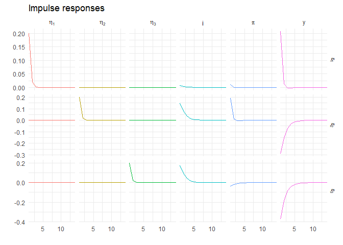

```r
y      <- data.matrix(select(dvalues, x, pi, i))
y      <- sweep(y, 2, apply(y, 2, mean))
namep  <- pvalues$`Parameter name`
thetp  <- pvalues$`Starting value`
pdf_p  <- select(pvalues, `PDF type`, mu, sigma)
bounds <- select(pvalues, `Lower bound`, `Upper bound`)
np     <- length(thetp)

# Impulse response for the initial parameter values
ir(thetp,nimp)
```

## Maximum likelihood

Maximum likelihood estimates are straightforwardly obtained by maximising the likelihood numerically.

```r
# Maximise likelihood
Hess <- diag(np)*0.001
ret_cmil <- csminwelNew(minus_likelihood,thetp,Hess,y,bounds,crit=1e-8,nit=200,Verbose=FALSE)
```

These estimates are:

```r
intv <- data.frame(Var=namep, m=ret_cmil$xh, sd=sqrt(diag(ret_cmil$H)))
knitr::kable(intv, caption = "Maximum likelihood estimates")
```

Maximum likelihood estimates

| Var | m | sd |
| --- | --- | --- |
| sigma | 0.7307455 | 0.2043694 |
| kappa | 0.0783078 | 0.0100715 |
| delta | 1.6241937 | 0.2082722 |
| gamma | 0.0009977 | 0.0043018 |
| rho[1] | 0.3055955 | 0.1580849 |
| rho[2] | 0.2271265 | 0.1297330 |
| rho[3] | 0.9137527 | 0.0183531 |
| sigma[1] | 0.0845579 | 0.0378248 |
| sigma[2] | 0.1523718 | 0.0610344 |
| sigma[3] | 0.3303321 | 0.1897332 |

We can plot these, and highlight $\pm 2$ standard errors, treating them like standard maximum likelihood estimates.

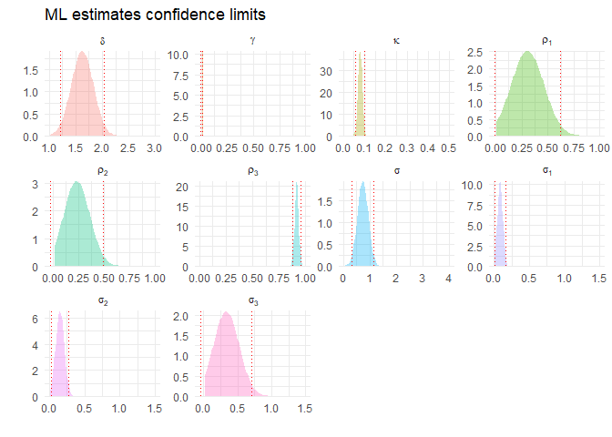

```r
ml_ci(intv,bounds) %>%
  ggplot() +
  geom_area(aes(x=d, y=v, fill=Var), alpha=.33, show.legend=FALSE) +
  geom_vline(data=intv,aes(xintercept=m-2*sd), color="red", linetype="dotted") +
  geom_vline(data=intv,aes(xintercept=m+2*sd), color="red", linetype="dotted") +
  facet_wrap(~Var, scales="free", labeller=label_parsed) +
  theme_minimal() +
  scale_y_continuous(expand=c(0, 0)) +
  labs(title="ML estimates confidence limits", x="", y="")
```

Implied impulse responses

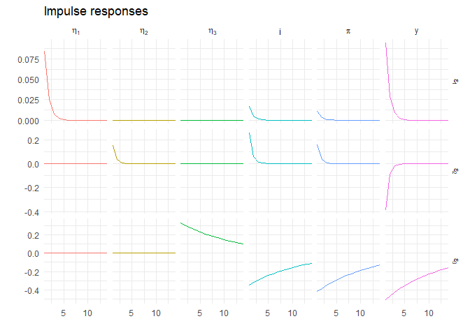

```r
ir(ret_cmil$xh,nimp)
```

## Bayesian estimation

Initialise search from maximised posterior

```r
# Bayesian
# Maximised posterior for initial values
ret_cmin <- csminwelNew(minus_posterior,thetp,Hess,y,bounds,pdf_p,crit=1e-8,nit=200,Verbose=FALSE)
```

Always some issues (which depend on the run): option `Vebose = TRUE` produces **a lot** more output. Now the MH loop, initialised using the maximised posterior

```r
# Metropolis Hastings algorithm
H     <- ret_cmin$H
K     <- 0.4
P     <- t(chol(H*K))       # Choleski decomp of H used as scale
bold  <- ret_cmin$xh        # starting value for DSGE parameters
pold  <- -ret_cmin$fh       # posterior at bold

# Store results in draws
draws <- data.frame(matrix(0, iters-burn, np+1))
colnames(draws) <- c(namep, "zlog_Posterior")

nacc  <- 0
nout  <- 0
for (i in 1:iters) {

  # step 1 Generate new draw from random walk
  bnew <- bold + P %*% matrix(rnorm(np), np, 1)

  # step 2 Evaluate Posterior at new draw
  pnew <- posterior(bnew, y, bounds, pdf_p)

  # step 3 compute acceptance probability
  if (pnew == -9999) {
    nout   <- nout + 1
    accept <- 0
    }
  else { accept <- min(c(exp(pnew-pold), 1)) }

  if (runif(1) < accept) {
    bold <- bnew
    pold <- pnew
    nacc <- nacc + 1
    }
  if (i > burn) { draws[i-burn,] <- c(bold, pold) }
}
```

## Results - convergence

First, check acceptance and out-of-bounds rates

```r
print(paste("Acceptance rate:",nacc/iters))
```

```
Answer:  [1] "Acceptance rate: 0.3254"
```

```r
print(paste("Out-of-bounds ratio:",nout/iters))
```

```
Answer:  [1] "Out-of-bounds ratio: 0.0906"
```

Seems OK — all we need do now is investigate the draws. First, put them in long form, adding an index for the draw number

```r
dd <- mutate(draws, draw=1:nrow(draws)) %>%
  gather(Var, Val, -draw)
```

To see if they have converged we plot the sequences

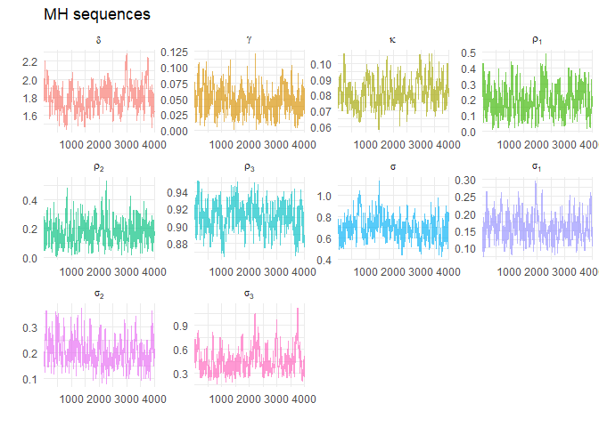

```r
ggplot(filter(dd, !Var=="zlog_Posterior")) +
  geom_line(aes(x=draw, y=Val, color=Var), alpha=.66, show.legend=FALSE) +
  facet_wrap(~Var, scales="free", labeller=label_parsed) +
  theme_minimal() +
  scale_x_continuous(expand=c(0, 0)) +
  labs(title="MH sequences", x="", y="")
```

## Results - estimates

As with the maximum likelihood estimates we can tabulate the results

```r
draws <- select(draws,-"zlog_Posterior")
mm    <- apply(draws, 2, mean)
qq    <- apply(draws, 2, quantile, c(.13, .87))
vv    <- apply(draws, 2, var)
hh    <- t(mapply(bayestestR::hdi, draws)) %>%
  data.frame() %>%
  select(-CI)
ml <- data.frame(mm, sqrt(vv), t(qq), hh, ret_cmin$xh, sqrt(diag(ret_cmin$H)))
colnames(ml) <- c("Post. mean", "Std err", "Int 13%", "Int 87%", "CI low", "CI high", "MaxPost", "Std err")
knitr::kable(ml, digits=4, caption="Estimation results")
```

Estimation results

|  | Post. mean | Std err | Int 13% | Int 87% | CI low | CI high | MaxPost | Std err |
| --- | --- | --- | --- | --- | --- | --- | --- | --- |
| sigma | 0.6948 | 0.1094 | 0.5764 | 0.8099 | 0.5145482 | 0.8524358 | 0.6849 | 0.1089 |
| kappa | 0.0816 | 0.0087 | 0.0723 | 0.0922 | 0.06830063 | 0.09452541 | 0.0798 | 0.0080 |
| delta | 1.7913 | 0.1416 | 1.6366 | 1.9490 | 1.564805 | 2.010229 | 1.7559 | 0.1364 |
| gamma | 0.0477 | 0.0207 | 0.0256 | 0.0744 | 0.0133254 | 0.08019642 | 0.0418 | 0.0226 |
| rho[1] | 0.1951 | 0.0887 | 0.0921 | 0.3028 | 0.05327044 | 0.3280542 | 0.1659 | 0.0972 |
| rho[2] | 0.1779 | 0.0834 | 0.0852 | 0.2724 | 0.03979554 | 0.292919 | 0.1697 | 0.0922 |
| rho[3] | 0.9109 | 0.0162 | 0.8923 | 0.9289 | 0.8854449 | 0.9378835 | 0.9107 | 0.0170 |
| sigma[1] | 0.1605 | 0.0368 | 0.1220 | 0.2014 | 0.102159 | 0.2167179 | 0.1452 | 0.0373 |
| sigma[2] | 0.2025 | 0.0532 | 0.1467 | 0.2711 | 0.1124022 | 0.2796974 | 0.1795 | 0.0478 |
| sigma[3] | 0.4560 | 0.1570 | 0.2926 | 0.6369 | 0.2378975 | 0.6823392 | 0.3820 | 0.1279 |

But we can do fab graphs too. Density estimates are

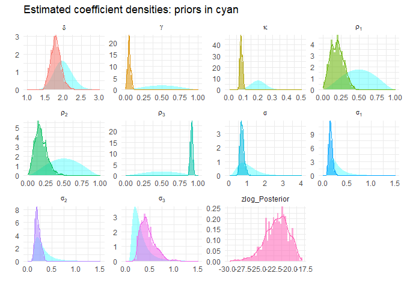

```r
# Shape of prior to plot in background
priors(namep,bounds,pdf_p) %>%
  ggplot() +
  geom_area(aes(x=d, y=v), fill="cyan", alpha=.33) +
  geom_histogram(data=dd, aes(x=Val, y=..density.., fill=Var), alpha=.55, bins=50) +
  geom_density(data=dd, aes(x=Val, color=Var), alpha=.66) +
  facet_wrap(~Var, scales="free", labeller=label_parsed) +
  theme_minimal() +
  theme(legend.position = "none") +
  scale_y_continuous(expand=c(0, 0)) +
  labs(title="Estimated coefficient densities: priors in cyan", x="", y="")
```

- Impulse response for the mean parameter values:

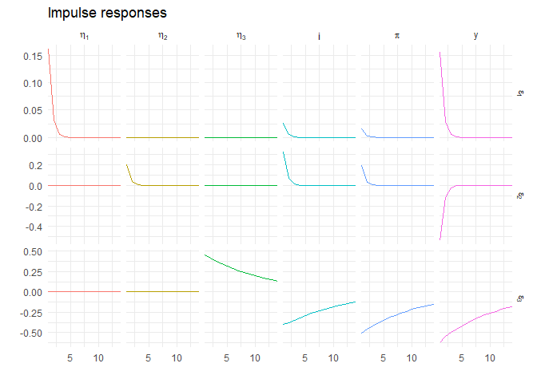

```r
ir(mm, nimp)
```